**Machine Learning for Mechanical Engineering**  
**Final Exam: Part II**  
**06/11/2025, 8:00 PM to 10:00 PM (120 minutes)**

Prof. Seungchul Lee  
http://iailab.kaist.ac.kr/  
Industrial AI Lab at KAIST

# Problem 01

(1) Suppose you have a dataset as depicted in the figure below. Can the perceptron algorithm classify this dataset?

```python
import numpy as np
import matplotlib.pyplot as plt
import tensorflow as tf
%matplotlib inline
```

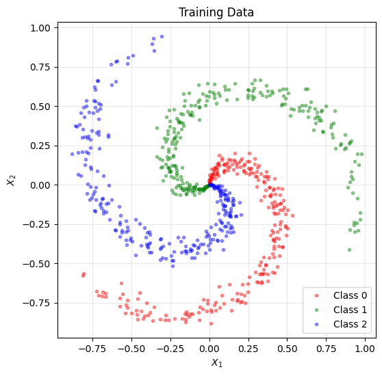

```python
# data generation (provided)

N = 250
n_class = 3

X, Y = [], []
r = np.linspace(0, 1, N)

for i in range(n_class):
    theta = np.linspace(4*i, 4*(i+1), N) + 0.2*np.random.randn(N)
    xp = np.array([r*np.sin(theta), r*np.cos(theta)])
    yp = i*np.ones(N)
    X.append(xp)
    Y.append(yp)

train_x = np.concatenate(X, axis = 1).T
train_y = np.concatenate(Y)

plt.figure(figsize = (6, 6))
plt.plot(train_x[train_y == 0,0], train_x[train_y == 0,1], 'r.', alpha = 0.4, label = 'Class 0')
plt.plot(train_x[train_y == 1,0], train_x[train_y == 1,1], 'g.', alpha = 0.4, label = 'Class 1')
plt.plot(train_x[train_y == 2,0], train_x[train_y == 2,1], 'b.', alpha = 0.4, label = 'Class 2')
plt.title('Training Data')
plt.legend(loc = 'lower right')
plt.xlabel('$X_1$')
plt.ylabel('$X_2$')
plt.grid(alpha = 0.3)
plt.show()
```

(2) In this problem, we aim to develop an ANN model specifically designed for tackling a multiclass non-linear classification problem.

```python
## here your code
#
```

Let's evaluate the accuracy for a new test dataset.

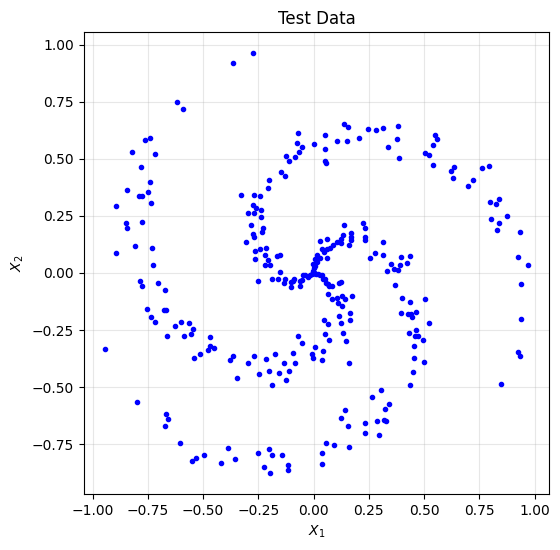

```python
## generate a new test dataset (provided)

m = 100
n_class = 3

X, Y = [], []
r = np.linspace(0, 1, m)

for i in range(n_class):
    theta = np.linspace(4*i, 4*(i+1), m) + 0.2*np.random.randn(m)
    xp = np.array([r*np.sin(theta), r*np.cos(theta)])
    yp = i*np.ones(m)
    X.append(xp)
    Y.append(yp)

test_x = np.concatenate(X, axis = 1).T
test_y = np.concatenate(Y)

plt.figure(figsize = (6, 6))
plt.title('Test Data')
plt.plot(test_x[test_y == 0,0], test_x[test_y == 0,1], 'b.')
plt.plot(test_x[test_y == 1,0], test_x[test_y == 1,1], 'b.')
plt.plot(test_x[test_y == 2,0], test_x[test_y == 2,1], 'b.')
plt.xlabel('$X_1$')
plt.ylabel('$X_2$')
plt.grid(alpha = 0.3)
plt.show()
```

(3) Calculate the accuracy for the test dataset and plot it with the predicted classes.

```python
## here your code
#
```

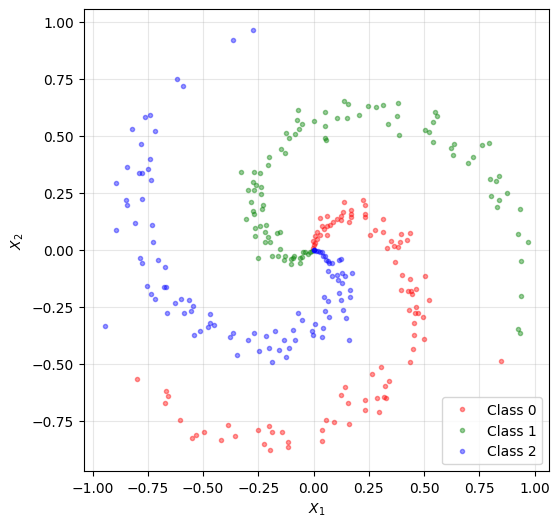

```python
# provided

predict = model.predict(test_x)
my_pred = np.argmax(predict, axis = 1)

plt.figure(figsize = (6, 6))
plt.plot(test_x[my_pred == 0,0], test_x[my_pred == 0,1], 'r.', alpha = 0.4, label = 'Class 0')
plt.plot(test_x[my_pred == 1,0], test_x[my_pred == 1,1], 'g.', alpha = 0.4, label = 'Class 1')
plt.plot(test_x[my_pred == 2,0], test_x[my_pred == 2,1], 'b.', alpha = 0.4, label = 'Class 2')
plt.legend(loc = 'lower right')
plt.xlabel('$X_1$')
plt.ylabel('$X_2$')
plt.grid(alpha = 0.3)
plt.show()
```

# Problem 2

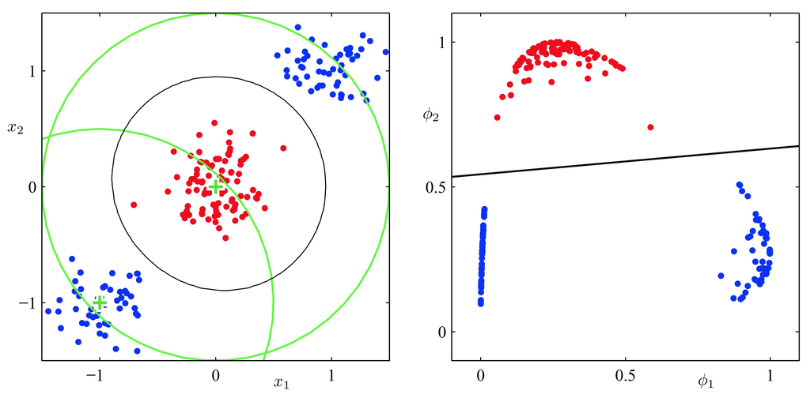

The left plot represents the original input space, where the following elements are illustrated:

1. Data Points: The plot shows two sets of data points corresponding to two classes:
   - Red points represent one class.
   - Blue points represent the other class.
2. Gaussian Basis Functions: Two Gaussian basis functions, $\phi_1(x)$ and $\phi_2(x)$, are defined in the input space. The green crosses represent the centers of the Gaussian basis functions, and their contours (shown by the green circles) indicate how the function values decrease as we move away from the center.
3. Nonlinear Decision Boundary: The black curve in the input space is the nonlinear decision boundary that separates the red and blue classes. This boundary was generated by a linear regression model, but it appears nonlinear due to the transformation into the feature space.

The right plot shows the corresponding feature space defined by the Gaussian basis functions:

1. Feature Space Transformation: The data points from the input space have been mapped into the feature space using the Gaussian basis functions $\phi_1(x)$ and $\phi_2(x)$. In this space, the red and blue points are clearly separable, making classification easier.
2. Linear Decision Boundary: The black line represents a linear decision boundary found by the linear regression model in the feature space.

In this problem, we will solve the non-linear binary classification problem using an artificial neural network (ANN).

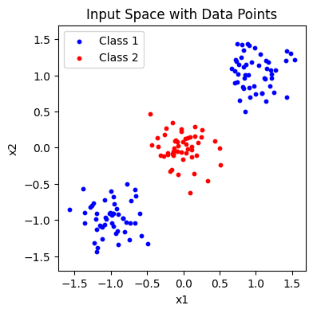

```python
## data generation
# do not need to change

import numpy as np
import matplotlib.pyplot as plt

np.random.seed(0)
num_points = 50
sigma = 0.05

blue_x_1 = np.random.multivariate_normal([-1, -1], [[sigma, 0], [0, sigma]], num_points)
blue_x_2 = np.random.multivariate_normal([1, 1], [[sigma, 0], [0, sigma]], num_points)
blue_x = np.concatenate((blue_x_1, blue_x_2), axis=0)

red_x = np.random.multivariate_normal([0, 0], [[sigma, 0], [0, sigma]], num_points)

# Plot the data points
plt.figure(figsize=(4, 4))
plt.scatter(blue_x[:, 0], blue_x[:, 1], s = 10, color='blue', label='Class 1')
plt.scatter(red_x[:, 0], red_x[:, 1], s = 10, color='red', label='Class 2')

plt.xlabel('x1')
plt.ylabel('x2')
plt.title('Input Space with Data Points')
plt.legend()
plt.axis('equal')
plt.show()
```

(1) Now, let's solve the problem using the following ANN structure. Then plot the linear classifier in $z$ space.

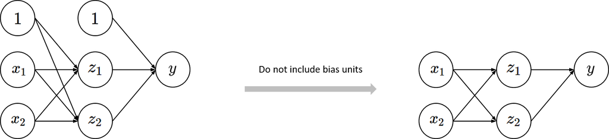

```python
## your code here
#
```

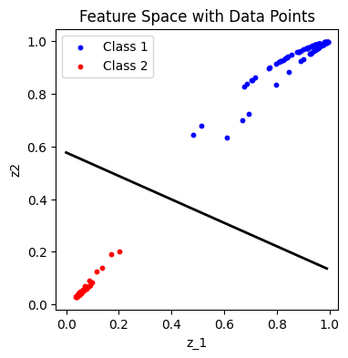

```python
## your code here
#
```

# Problem 3

We would like to observe a 'walk in the latent space' using an autoencoder. Please use the rotated MNIST digit 1

```python
import numpy as np
import matplotlib.pyplot as plt
import cv2
import imutils
import random
import tensorflow as tf
%matplotlib inline

# Load Data
mnist = tf.keras.datasets.mnist

(train_x, train_y), (test_x, test_y) = mnist.load_data()
train_x, test_x = train_x.reshape(-1, 784)/255.0, test_x.reshape(-1, 784)/255.0
```

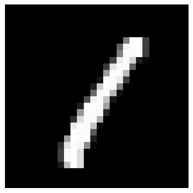

```python
img = train_x[3]
img = img.reshape(28, 28)

plt.imshow(img, 'gray')
plt.axis('off')
plt.show()
```

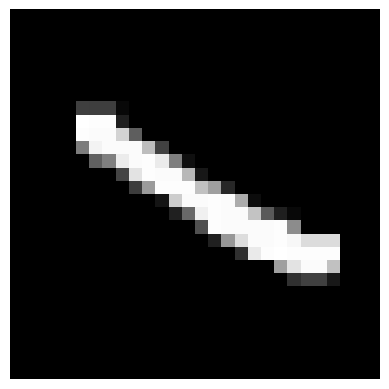

```python
rotated_img = imutils.rotate(img, angle = 90)

plt.imshow(rotated_img, 'gray')
plt.axis('off')
plt.show()
```

rotMNIST is a dataset consisting of 1,000 images of 1, where digit 1 are randomly rotated between 0 and 90 degrees

```python
rotMNIST = []

for i in range(1000):
  rotated_img = imutils.rotate(img, angle = random.randint(0, 90))
  rotMNIST.append(rotated_img.reshape(-1, 1))

rotMNIST = np.array(rotMNIST)
```

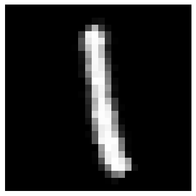

```python
plt.imshow(rotMNIST[random.randint(0, 1000)].reshape(28,28), 'gray')
plt.axis('off')
plt.show()
```

(1) Write an autoencoder code with a latent space of one neuron.

```python
## your code here
#
```

(2) Visualize the reconstructed image.

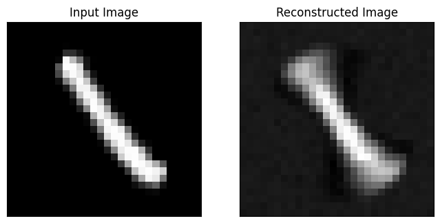

```python
## your code here
#
```

(3) Plot the histogram of the latent values of rotMNIST to see the distribution of latent variables.

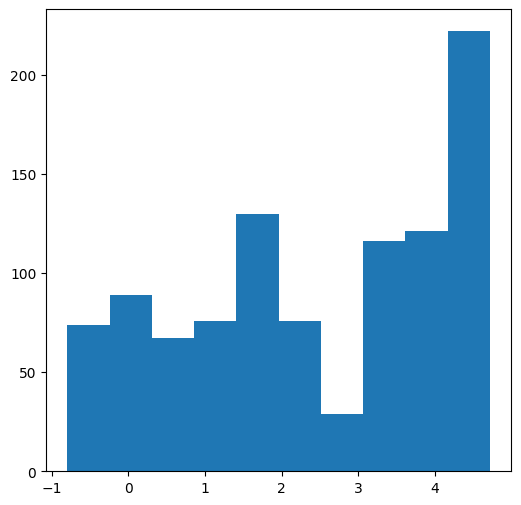

```python
## your code here
#
```

(4) Generate fake images by walking through the latent space. Discuss what the encoder has learned from the rotMNIST dataset.

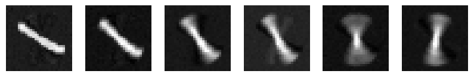

```python
## your code here
#
```

# Problem 04

Anomaly detection is a technique used to identify unusual patterns that do not conform to expected behavior, called outliers. Typically, this is treated as an unsupervised learning problem where the anomalous samples are not known a priori and it is assumed that the majority of the training dataset consists of "normal" data.

In the context of the MNIST dataset, let's consider digit 7 as representative of "normal" data. We will exclusively train an autoencoder using this "normal" data to enable the model to capture the features inherent to this normal data. As a result, it is reasonable to expect that when anomalous data is input into this trained autoencoder, the reconstruction performance will not be ideal. In other words, the reconstruction error, often referred to as the anomaly score, for anomalous data will likely be greater than that for normal data.

```python
import tensorflow as tf
import numpy as np
import matplotlib.pyplot as plt
```

```python
# Load Data

(train_imgs, train_labels), (test_imgs, test_labels) = tf.keras.datasets.mnist.load_data()
train_imgs, test_imgs = train_imgs.reshape(-1, 784)/255.0, test_imgs.reshape(-1, 784)/255.0
```

(1) Designate digit 7 as representative of "normal" data. Extract all occurrences of digit 7 from `train_imgs` and `test_imgs`, creating new datasets named `normal_train_imgs` and `normal_test_imgs`, respectively.

```python
## here your code
#
```

(2) Design an autoencoder model and train it using the `normal_train_imgs` dataset.

```python
## here your code
#
```

```python
# provided

training = autoencoder.fit(normal_train_imgs, normal_train_imgs, batch_size = 50, epochs = 10)
```

(3) Randomly select an image from `normal_test_imgs` and display its reconstructed image.

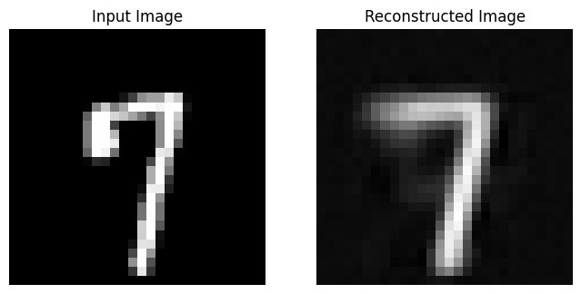

```python
## here your code
#
```

(4) Digit 5 will be considered as representative of "abnormal" data. Extract all digit 5 from `test_imgs` and create new datasets named `abnormal_test_imgs`.

```python
## here your code
#
```

(5) Randomly select one image from the `abnormal_test_imgs` dataset and display its reconstructed image.

- Note that the reconstruction performance is not as good as that of normal data. This is expected because the autoencoder was trained primarily on normal data, and its ability to reconstruct abnormal data is limited.

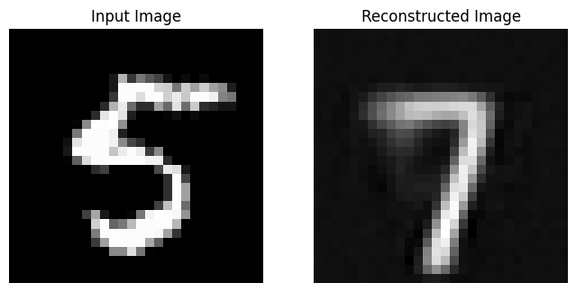

```python
## here your code
#
```

(6) Compute and plot anomaly scores for the first 200 normal test images and the first 200 abnormal test images. To do this, you can calculate the reconstruction error (anomaly score) for each image and then create plots to visualize these scores. This will help you identify anomalies among the test images.

- Use the mean squared error as the anomaly score
- After computing the anomaly scores for both normal and abnormal test images, you can set a threshold to differentiate between normal and abnormal images based on the anomaly scores. The threshold will determine what level of anomaly score is considered "anomalous."
- Select a threshold value based on your visual inspection.

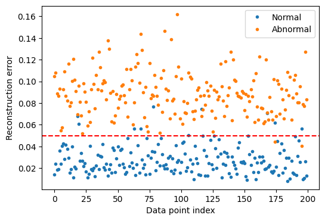

```python
## here your code
#
```

# Problem 05

We intend to perform multiple tasks with the Fashion MNIST dataset. For more details, please refer to the description provided at the following link: https://keras.io/api/datasets/fashion_mnist/

You have the freedom to design your own network structures according to your preferences.

```python
# Import Library
import numpy as np
import matplotlib.pyplot as plt
import tensorflow as tf
```

```python
# load fashion _mnist data set

(train_x, train_y), (test_x, test_y) = tf.keras.datasets.fashion_mnist.load_data()
train_y = tf.keras.utils.to_categorical(train_y, 10)
test_y = tf.keras.utils.to_categorical(test_y, 10)
```

(1) Perform image classification utilizing CNN.

- Use all 10 classes
- Display a randomly selected test image with its corresponding prediction
- Compute the accuracy using 100 randomly chosen samples

```python
## here your code
#
```

(2) Use an autoencoder with only three classes (Sandal, Sneaker, Ankle boot)

- Set two neurons for the latent space and visualize compressed data in the latent space
- Show one reconstructed image with the original image

```python
## here your code
#
```

# Problem 06

In this problem, we are going to perform anomaly detection using LSTM layers.

- The dataset given below is composed of data from four bearing sensors on a single bearing. In other words, there were four sensors attached to the bearing. The main objective of this problem is to find the exact moment in the test dataset where bearing started to malfunction. We will use the difference between the predicted value and the measured value as the criterion for determining a malfunction.

(1) Load the data which you can download it from this [link](https://drive.google.com/file/d/1uGeR5CD3FI-nWr3dtzWBDsV7PVL6Oc_t/view?usp=sharing)

```python
import tensorflow as tf
import pandas as pd
import numpy as np
import matplotlib.pyplot as plt
import random
```

```python
from google.colab import drive
drive.mount('/content/drive')
```

```python
# change the path according to yours

AD_bearing = np.load('/content/drive/MyDrive/ML_Colab/ML_data/AD_bearing.npy')
print("Shape of total data: ", AD_bearing.shape)
```

```
Shape of total data:  (6324, 4)
```

(2) Plot the given dataset.

- There were four sensors attached to the bearing and each sensor is named 'Bearing 1', 'Bearing 2', 'Bearing 3', and 'Bearing 4'

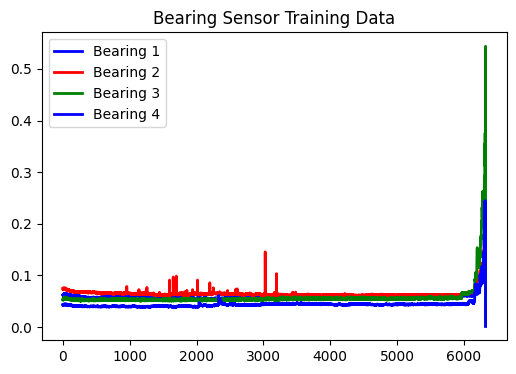

```python
## here your code
#
```

(3) Divide the dataset into training and testing subsets.

- We will use 'Bearing 3' only (i.e., data[:,2])
- Select the initial 4000 data points from the original dataset as the training data
- Allocate the remaining data points as the test data
- Plot the entire data and mark datapoints that belong to train and test dataset with different colors

```python
## here your code
#
```

```
Training dataset shape: (4000, 1)
Test dataset shape: (2324, 1)
```

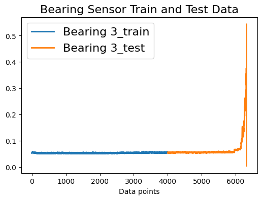

```python
## here your code
#
```

(4) Construct the LSTM model based on the provided model structure below.

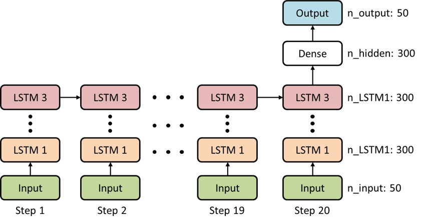

```python
## here your code
#
```

```
Model: "sequential"
_________________________________________________________________
 Layer (type)                Output Shape              Param #
=================================================================
 lstm (LSTM)                 (None, 20, 300)           421200

 lstm_1 (LSTM)               (None, 20, 300)           721200

 lstm_2 (LSTM)               (None, 300)               721200

 dense (Dense)               (None, 300)               90300

 dense_1 (Dense)             (None, 50)                15050

=================================================================
Total params: 1968950 (7.51 MB)
Trainable params: 1968950 (7.51 MB)
Non-trainable params: 0 (0.00 Byte)
_________________________________________________________________
```

(5) Change the structure of the data so that it can be used in the LSTM structure and train the model

```python
## here your code
#
```

(6) Check how well the model predicts the next 50 data points when the first 1000 data points of the training data are given to the model. (Plot as below)

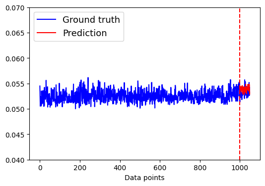

```python
## here your code
#
```

(7) Plot both measured and predicted signals to visualize their difference.

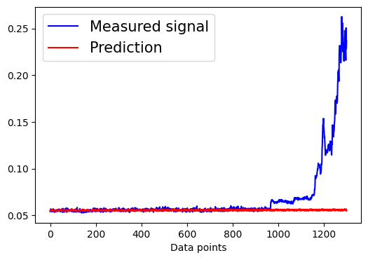

```python
## here your code
#
```

(8) Set the following threshold value to determine from which data point a malfunction occurred (plot as below)

- Threshold: 0.007

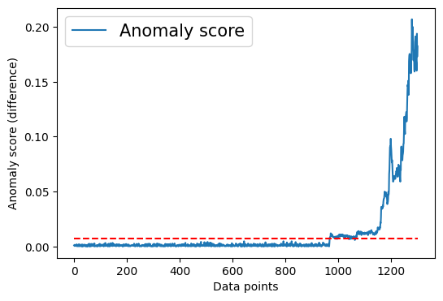

```python
## here your code
#
```

# Problem 08:

In this problem, you will use a Physics-Informed Neural Network (PINN) to solve the one-dimensional heat conduction equation over a finite rod.

**Governing Equation**

The temperature distribution $u(x,t)$ along a rod of length $L$ is governed by the 1D heat equation:

$$ \frac{\partial u}{\partial t} = \alpha \frac{\partial^2 u}{\partial x^2}, \quad 0 < x < L,\ t > 0 $$

where $\alpha > 0$ is the thermal diffusivity.

**Initial Condition**

$$ u(x, 0) = \sin(\pi x), \quad 0 \leq x \leq L $$

**Boundary Conditions (Dirichlet)**

$$ u(0, t) = 0, \quad u(L, t) = 0, \quad t \geq 0 $$

**Parameters**

- Length of the rod: $L = 1$
- Thermal diffusivity: $\alpha = 0.01$
- Final time: $T = 1$

**PINN Setup**

Train a neural network $\hat{u}(x, t; \theta)$ such that:

1. It satisfies the heat equation at collocation points in the domain $(x, t) \in (0, 1) \times (0, T]$
2. It matches the initial condition at $t = 0$
3. It satisfies the boundary conditions at $x = 0$ and $x = 1$

**Loss Function**

The total loss function is composed of three terms:

$$ \mathcal{L}(\theta) = \mathcal{L}_{\text{PDE}} + \mathcal{L}_{\text{IC}} + \mathcal{L}_{\text{BC}} $$

- $\mathcal{L}_{\text{PDE}}$: Residual loss enforcing the heat equation
- $\mathcal{L}_{\text{IC}}$: Loss enforcing the initial condition
- $\mathcal{L}_{\text{BC}}$: Loss enforcing the boundary conditions

**Expected Outcome**

The trained PINN should approximate the analytical solution:

$$ u(x, t) = e^{-\pi^2 \alpha t} \sin(\pi x) $$

This expression may be used for validation and error analysis.

**Task**

(1) Using the information above, implement a PINN to approximate the solution $u(x, t)$, and compare it with the exact solution by plotting both.

```python
## your code here
#
```

# Problem 08

In this problem, we will solve a solid mechanics problem with PINN.

- Given the situation below, compute the displacement of the beam in y direction
- Unlike the example from class, this time we will use Dirac delta function to represent the point load (P)

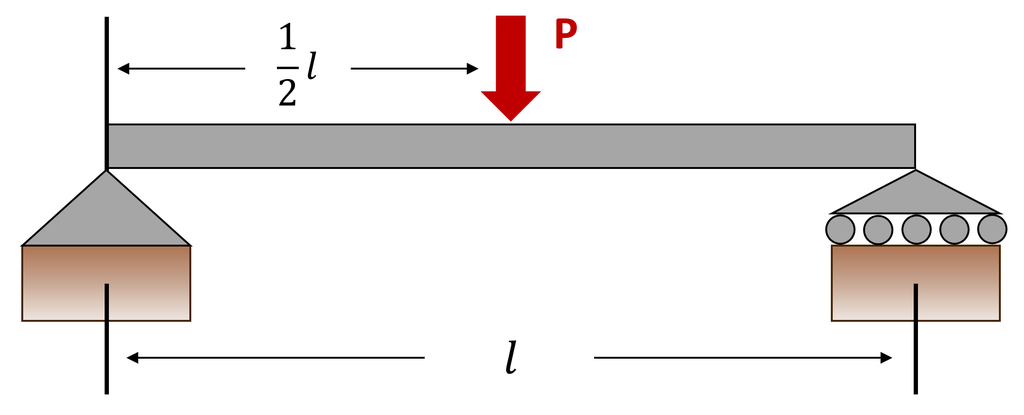

- Problem properties

$$E = 1 \operatorname{pa}, \quad I = 1 \operatorname{kg\cdot m^2}, \quad P = 1 \operatorname{N}, \quad l = 1 \operatorname{m}$$

- Partial differential equations & boundary conditions

$${\partial^4 y \over \partial x^4} + \delta \left(x - {1 \over 2} \right) = 0, \qquad \text{where} \quad x \in [0,1]$$

- Here, $\delta (x)$ is the [Dirac delta function](https://en.wikipedia.org/wiki/Dirac_delta_function)
- Dirichlet boundary condition:

$$u(0) = 0$$

$$u(1) = 0$$

- Free moment condition:

$$u''(0) = 0$$

$$u''(1) = 0$$

- The exact solution is given as follows:

$$ y(x) = \begin{cases} \frac{1}{48} (4x^3 - 3x) & x \in \left[0, \frac{1}{2} \right]\\ \frac{1}{48} (-4x^3 + 12x^2 - 9x + 1) & x \in \left[\frac{1}{2}, 1 \right] \end{cases} $$

**Hint**

In applied mathematics, the delta function is often manipulated as a kind of limit (a weak limit) of a sequence of functions, each member of which has a tall spike at the origin: for example, a sequence of Gaussian distributions centered at the origin with variance tending to zero.

$$ \delta (x-x_0) = \frac{1}{\sigma \sqrt{2 \pi}} e^{-\frac{1}{2} {\left( \frac{x - x_0}{\sigma}\right)}^2 } $$

- Set $\sigma = 0.1$ and $x_0 = 0.5$

(1) Use PINN to approximate the solution

```python
## your code here
#
```

(2) Compare your result with a true solution

```python
## your code here
#
```